# Kruskal Wallis toets

Disclaimer: Het peer review proces voor deze toets is nog niet afgerond; daarom is deze pagina nog in concept.

# 1 Toepassing

# 2 Onderwijscasus

De opleidingsdirecteur van de tweejarige Masteropleiding Arbeidsrecht is geïnteresseerd in de afstudeersnelheid van haar studenten. Zij vraagt zich af of er een verschil zit in het type vooropleiding dat de studenten hebben gehaald en de hoeveel studiepunten die de studenten behalen in het eerste jaar. Zij kijkt naar de vier meest gangbare vooropleidingen die de studenten doorlopen voordat ze met de Master Arbeidsrecht beginnen: de Bachelors Fiscaal Recht, Notarieel Recht en Rechtsgeleerdheid en de Premaster.

Dit onderzoek vertaalt zich in de volgende combinatie van hypothesen, waarbij de nulhypothese zo geformuleerd is dat er geen effect of verschil is en de alternatieve hypothese zo geformuleerd is dat er wel een effect of verschil is.

*H<sub>0</sub>*: Het gemiddelde rangnummer van de verdeling van het aantal behaalde studiepunten in het eerste jaar van de master Arbeidsrecht is gelijk voor de studenten met als vooropleidingen Bachelor Fiscaal Recht, Notarieel Recht of Rechtsgeleerdheid of de Premaster.

*H<sub>A</sub>*: Het gemiddelde rangnummer van de verdeling van het aantal behaalde studiepunten in het eerste jaar van de master Arbeidsrecht is niet gelijk voor de studenten met als vooropleiding Bachelor Fiscaal Recht, Notarieel Recht of Rechtsgeleerdheid of de Premaster.

# 3 Assumpties

Het meetniveau van de afhankelijke variabele is ordinaal[^5] of continu.[^6] In deze toetspagina staat een casus met continue data centraal; een casus met ordinale data met bijbehorende uitwerking is te vinden in de Kruskal Wallis toets II.

# 4 Post-hoc toets

De *Kruskal Wallis toets* toetst of twee of meerdere groepen van elkaar verschillen. Een post-hoc toets specificeert of groep significant van een andere groep verschilt. Gebruik de Mann-Whitney U toets als post-hoc toets. Hoewel het minder gebruikelijk is, is *Moods’mediaan toets* ook een optie als post-hoc toets. Deze toets toetst het verschil tussen de medianen van twee ongepaarde groepen. De Mann-Whitney U toets toetst het verschil tussen de verdelingen van twee ongepaarde groepen.

Gebruik een correctie voor de p-waarden, omdat er meerdere toetsen tegelijkertijd worden gebruikt. Meerdere toetsen tegelijkertijd uitvoeren verhoogt de kans dat een van de nulhypotheses onterecht wordt verworpen en er bij toeval een verband wordt ontdekt dat er niet is (type I fout). In deze toetspagina wordt de *Bonferroni correctie* gebruikt. Deze correctie past de p-waarde aan door de p-waarde te vermenigvuldigen met het aantal uitgevoerde toetsen en verlaagt hiermee de kans op een type I fout.[^7] Een andere uitleg hiervan is dat het significantieniveau gedeeld wordt door het aantal toetsen wat leidt tot een lager significantieniveau en dus een strengere toets. Er zijn ook andere opties voor een correctie op de p-waarden.[^8]

# 5 Effectmaat

De p-waarde geeft aan of het verschil tussen groepen significant is. De grootte van het verschil of effect is echter ook relevant. Een effectmaat is een gestandaardiseerde maat die de grootte van een effect weergeeft, zodat effecten van verschillende onderzoeken met elkaar vergeleken kunnen worden.[^9]

Bij de *Kruskal Wallis toets* wordt eta-squared (*η<sup>2</sup>*) als effectmaat gebruikt.[^10] De effectmaat eta squared (*η<sup>2</sup>*) berekent de proportie van de variantie in de afhankelijke variabele die verklaard wordt door de onafhankelijke variabele. In deze casus berekent het de proportie van de variantie in het aantal studiepunten wat verklaard kan worden door de vooropleiding. Een indicatie om *η<sup>2</sup>* te interpreteren is: rond 0,01 is een klein effect, rond 0,06 is een gemiddeld effect en rond 0,14 is een groot effect.[^11]

# 6 Uitvoering

Er is een dataset `dfResultaten_Arbeidsrecht` ingeladen met studieresultaten van het eerste jaar van de master Arbeidsrecht per vooropleiding: Fiscaal Recht, Notarieel Recht, Rechtsgeleerdheid en de Premaster.

## 6.1 De data bekijken

Gebruik `<dataframe>.head()` en `<dataframe>.tail()` om de structuur van de data te bekijken.

```python
import pandas as pd
## Eerste 6 observaties
print(dfResultaten_Arbeidsrecht.head(6))
##    Studentnummer    Vooropleiding  EC_Jaar1
## 0        3807246        Premaster      42.0
## 1        3915405        Premaster      36.0
## 2        3188059    Fiscaal Recht      60.0
## 3        3098956  Notarieel Recht      48.0
## 4        3367486    Fiscaal Recht      48.0
## 5        3590979        Premaster      12.0
```

```python
## Laatste 6 observaties
print(dfResultaten_Arbeidsrecht.tail(6))
##      Studentnummer      Vooropleiding  EC_Jaar1
## 294        3442156          Premaster      42.0
## 295        3757991  Rechtsgeleerdheid      54.0
## 296        3783610  Rechtsgeleerdheid      36.0
## 297        3055956      Fiscaal Recht      66.0
## 298        3041376  Rechtsgeleerdheid       0.0
## 299        3395844      Fiscaal Recht      60.0
```

De dataset bevat data van studenten van verschillende vooropleidingen. Gebruik `<data.frame>.<kolomnaam>.unique()` om te onderzoeken welke opleidingen er in de data aanwezig zijn.

```python
## Opleidingen in de data aanwezig
print(dfResultaten_Arbeidsrecht['Vooropleiding'].unique())
```

```
## ['Premaster' 'Fiscaal Recht' 'Notarieel Recht' 'Rechtsgeleerdheid']
```

Inspecteer om meer inzicht te krijgen in de data de groepen met `.size()` en `.quantile()`. Groepeer hiervoor eerst met `<dataframe>.groupby([<column>])`. De mediaan is gelijk aan kwantiel `0.5`.

```python
print(dfResultaten_Arbeidsrecht.groupby(['Vooropleiding']).size())
```

```
## Vooropleiding
## Fiscaal Recht        71
## Notarieel Recht      77
## Premaster            81
## Rechtsgeleerdheid    71
## dtype: int64
```

```python
print(dfResultaten_Arbeidsrecht.groupby(['Vooropleiding']).quantile([0.25, 0.5, 0.75]))
```

```
##                         Studentnummer  EC_Jaar1
## Vooropleiding
## Fiscaal Recht     0.25      3326401.5      30.0
##                   0.50      3609937.0      54.0
##                   0.75      3787836.0      66.0
## Notarieel Recht   0.25      3168105.0      42.0
##                   0.50      3543586.0      54.0
##                   0.75      3778668.0      60.0
## Premaster         0.25      3264950.0      30.0
##                   0.50      3494636.0      42.0
##                   0.75      3704366.0      54.0
## Rechtsgeleerdheid 0.25      3175899.5      21.0
##                   0.50      3435286.0      36.0
##                   0.75      3720481.0      48.0
```

## 6.2 De data visualiseren

Geef de verdeling van de verschillende vooropleidingen visueel weer met een histogram.[^12]

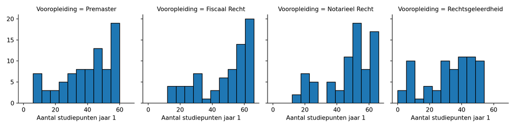

```python
# Laad seaborn of facets te maken
import seaborn as sb
# Laad matplotlib.pyplot om plots te maken
import matplotlib.pyplot as plt

# Maak een facet plot met een histogram voor elke vooropleiding
g = sb.FacetGrid(dfResultaten_Arbeidsrecht, col="Vooropleiding")
g = (g.map(plt.hist, "EC_Jaar1", edgecolor = "black").set_axis_labels("Aantal studiepunten jaar 1"))
plt.show()
```